# Case study: How does a bike-share navigate speedy success?

As a junior data analyst working in the marketing analyst team of Cyclistic, a bike-share company in Chicago, the director of marketing believes that the company's future success depends on maximizing the number of annual memberships and with that being the case, our team was tasked to understand how casual riders and annual members use Cyclistic bikes differently.

From these insights, our team will design a new marketing strategy to convert casual riders into annual members.

However, the executives must first approve of our recommendations. In which, must be backed up with compelling data insights and professional data visualizations.

## Case information

### Characters and teams

- **Cyclistic:** A bike-share program that features more than 5,800 bicycles and 600 docking stations. Cyclistic sets itself apart by also offering reclining bikes, hand tricycles, and cargo bikes, making bike-share more inclusive to people with disabilities and riders who can’t use a standard two-wheeled bike. The majority of riders opt for traditional bikes; about 8% of riders use the assistive options. Cyclistic users are more likely to ride for leisure, but about 30% use them to commute to work each day.
- **Lily Moreno:** The director of marketing and your manager. Moreno is responsible for the development of campaigns and initiatives to promote the bike-share program. These may include email, social media, and other channels.
- **Cyclistic marketing analytics team:** A team of data analysts who are responsible for collecting, analyzing, and reporting data that helps guide Cyclistic marketing strategy. You joined this team six months ago and have been busy learning about Cyclistic’s mission and business goals — as well as how you, as a junior data analyst, can help Cyclistic achieve them.
- **Cyclistic executive team:** : The notoriously detail-oriented executive team will decide whether to approve the recommended marketing program.

### About the company

In 2016, Cyclistic launched a successful bike-share offering. Since then, the program has grown to a fleet of 5,824 bicycles that are geotracked and locked into a network of 692 stations across Chicago. The bikes can be unlocked from one station and returned to any other station in the system anytime.

Until now, Cyclistic’s marketing strategy relied on building general awareness and appealing to broad consumer segments. One approach that helped make these things possible was the flexibility of its pricing plans: single-ride passes, full-day passes, and annual memberships. Customers who purchase single-ride or full-day passes are referred to as casual riders. Customers who purchase annual memberships are Cyclistic members

Cyclistic’s finance analysts have concluded that annual members are much more profitable than casual riders. Although the pricing flexibility helps Cyclistic attract more customers, Moreno believes that maximizing the number of annual members will be key to future growth. Rather than creating a marketing campaign that targets all-new customers, Moreno believes there is a very good chance to convert casual riders into members. She notes that casual riders are already aware of the Cyclistic program and have chosen Cyclistic for their mobility needs.

Moreno has set a clear goal: Design marketing strategies aimed at converting casual riders into annual members. In order to do that, however, the marketing analyst team needs to better understand how annual members and casual riders differ, why casual riders would buy a membership, and how digital media could affect their marketing tactics. Moreno and her team are interested in analyzing the Cyclistic historical bike trip data to identify trends.

### Scope of work and roadmap

| Deliverables | Key tasks | Guiding questions |
| --- | --- | --- |
| A clear statement of the business task | Identify the business tasks Consider key stakeholders | 1. What is the problem you're trying to solve 2. How can your insights drive business decisions |
| A description of all data sources used | Download the data and store it appropriately Identify how it's being organized Sort and filter the data Determine the credibility of the data. | 1. Where is your data located? 2. How is the data organized? 3. Are there issues with bias or credibility in this data? Does your data ROCCC? 4. How are you addressing licensing, privacy, security, an… |
| Documentation of any cleaning or manipulation of data | Check the data for errors. Choose your tools. Transform the data so you can work with it effectively. Document the cleaning process. | 1. What tools are you choosing and why? 2. Have you ensured your data’s integrity? 3. What steps have you taken to ensure that your data is clean? 4. How can you verify that your data is clean and rea… |
| A summary of analysis | Aggregate your data so it’s useful and accessible. Organize and format your data. Perform calculations. Identify trends and relationships. | 1. How should you organize your data to perform analysis on it? 2. Has your data been properly formatted? 3. What surprises did you discover in the data? 4. What trends or relationships did you find i… |
| Supporting visualizations and key findings | Determine the best way to share your findings. Create effective data visualizations. Present your findings. Ensure your work is accessible. | 1. Were you able to answer the question of how annual members and casual riders use Cyclistic bikes differently? 2. What story does your data tell? 3. How do your findings relate to your original ques… |
| Top three recommendations based on analysis | Create your portfolio. Add your case study. Practice presenting your case study to a friend or family member. | 1. What is your final conclusion based on your analysis? 2. How could your team and business apply your insights? 3. What next steps would you or your stakeholders take based on your findings? 4. Is t… |

## Execution

### 1. Defining the problem

#### Company background

Cyclistic is a bike share company that offers short-term bicycle rentals to customers in the city of Chicago. They have a fleet of bicycles that are stationed at various docking stations across the city. Customers can rent the bicycles for a specified period and return them to any docking station in the city.

Cyclistic differentiates itself from its competitors by providing a premium experience to its customers. They offer two types of memberships: casual pass and annual membership. The casual pass allows customers to rent a bicycle for a single ride, while the annual membership provides unlimited rides for a flat fee.

To sustain and grow its business, Cyclistic needs to understand its customer base, identify usage patterns, and optimize its operations. This case study aims to address the following problem statement:

#### Problem statement

Cyclistic wants to understand how customers' usage patterns differ between the casual pass and annual membership holders. By analyzing the data, they seek to identify trends and patterns that can help them make strategic business decisions to increase the number of annual members and enhance the overall customer experience.

The specific objectives of the problem statement are as follows:

- **Differentiation of Usage Patterns:** Determine the differences in usage patterns between casual pass users and annual members. Identify peak usage times, popular docking stations, trip durations, and other relevant factors that influence customers' preferences.
- **User Segmentation:** Segment the customer base based on usage patterns, demographics, or any other relevant factors. Understand the characteristics and needs of different customer segments to tailor marketing efforts and improve customer targeting.
- **Promotion Optimization:** Analyze the effectiveness of current promotional strategies for converting casual pass users into annual members. Identify opportunities for improving the conversion rate and recommend targeted promotions to attract more annual members.
- **Operational Efficiency:** Identify operational inefficiencies or bottlenecks, such as bike availability, docking station capacity, or maintenance issues, that may impact customer experience. Propose solutions to improve operational efficiency and ensure a seamless bike sharing experience for customers.
- **Revenue Generation:** Explore opportunities to increase revenue by optimizing pricing strategies, introducing new services or membership tiers, or forming partnerships with other businesses in the transportation or tourism industry.

#### Stakeholders goals and expectations

| Stakeholder | Goals | Expectations |
| --- | --- | --- |
| Lily Moreno | Design marketing strategies aimed at converting casual riders into annual members. | Data-driven, accurate, and reliable insights and analysis from the marketing analytics team |
| Cyclistic marketing analytics team | Produce a data-driven, accurate, and reliable insights and analysis results to support the goals of executive stakeholders | Determine the differences, patterns, and relationships in the usage of customer types |
| Cyclistic executive team | Actionable key-findings and recommendations based on the insights derived from the analysis | Implement effective marketing strategies for growth and success from leveraging data-driven insights |

### 2. Data preparation and storing information

#### Data source and organization

The data used for the case study on Cyclistic is sourced from https://divvy-tripdata.s3.amazonaws.com/index.html. Made available by Motivate International Inc. under this [license](https://ride.divvybikes.com/data-license-agreement) The dataset contains historical data on bike rides. In which, contains the columns:

- **ride_id:** A unique identifier for each bike ride.
- **rideable_type:** The type of bike for which what the user used for the bike ride.
- **started_at:** The timestamp indicating the start time of the ride.
- **ended_at:** The timestamp indicating the end time of the ride.
- **start_station_name:** The name or location description of the docking station where the ride started.
- **start_station_id:** The unique identifier of the docking station where the ride started.
- **end_station_name:** The name or location description of the docking station where the ride ended.
- **end_station_id:** The unique identifier of the docking station where the ride ended.
- **start_lat:** The latitude coordinate of the docking station where the ride started.
- **start_lng:** The longitude coordinate of the docking station where the ride started.
- **end_lat:** The latitude coordinate of the docking station where the ride ended.
- **end_lng:** The longitude coordinate of the docking station where the ride ended.
- **member_casual:** The type of user, indicating whether the customer is a casual pass user or an annual member.

Merging the trip data dataset from year 2022 months june-december and year 2023 january-may

```r
# Loading required library
library(tidyverse)
library(geosphere)
library(ggbeeswarm)
library(hash)
library(scales)
library(viridis)

options(readr.show_col_types = FALSE)
options(scipen = 999)
```

```r
# Making a list of the numeric values of months in the yearmonth prefix of dataset filenames
# e.g. for year 2022 month of january, 202201-divvy-tripdata.csv
filename_record_prefix_2022 = list(6:12)
filename_record_prefix_2023 = list(1:5)

# Making a function to merge datasets by year and month range
merge_data_by_year_and_month_range <- function(year, filename_record_prefix) {
    # Initializing df as null for binding
    df <- NULL

    for (filename_prefix in filename_record_prefix){
        formatted_filename_prefix <- sprintf("%02d", filename_prefix)
        df <- rbind(df, read_csv(glue::glue("data/csv/raw/{year}{formatted_filename_prefix}-divvy-tripdata.csv")))
    }

    # Returning the merged data
    return(df)
}

df <- rbind(
    merge_data_by_year_and_month_range(2022, filename_record_prefix_2022),
    merge_data_by_year_and_month_range(2023, filename_record_prefix_2023)
)

# Casting data as tibble
df <- as_tibble(df)
```

```r
glimpse(df)
```

```
Rows: 5,829,030
Columns: 13
$ ride_id            <chr> "600CFD130D0FD2A4", "F5E6B5C1682C6464", "B6EB6D27BA…
$ rideable_type      <chr> "electric_bike", "electric_bike", "electric_bike", …
$ started_at         <dttm> 2022-06-30 17:27:53, 2022-06-30 18:39:52, 2022-06-…
$ ended_at           <dttm> 2022-06-30 17:35:15, 2022-06-30 18:47:28, 2022-06-…
$ start_station_name <chr> NA, NA, NA, NA, NA, NA, NA, NA, NA, NA, NA, NA, NA,…
$ start_station_id   <chr> NA, NA, NA, NA, NA, NA, NA, NA, NA, NA, NA, NA, NA,…
$ end_station_name   <chr> NA, NA, NA, NA, NA, NA, NA, NA, NA, NA, NA, NA, NA,…
$ end_station_id     <chr> NA, NA, NA, NA, NA, NA, NA, NA, NA, NA, NA, NA, NA,…
$ start_lat          <dbl> 41.89, 41.91, 41.91, 41.80, 41.91, 42.03, 41.91, 41…
$ start_lng          <dbl> -87.62, -87.62, -87.65, -87.66, -87.63, -87.71, -87…
$ end_lat            <dbl> 41.91, 41.93, 41.89, 41.80, 41.93, 42.06, 41.92, 41…
$ end_lng            <dbl> -87.62, -87.63, -87.61, -87.65, -87.64, -87.73, -87…
$ member_casual      <chr> "casual", "casual", "casual", "casual", "casual", "…
```

Checking for the total number of duplicated observations

```r
df %>%
select(ride_id) %>%
duplicated() %>%
sum()
```

0

Checking for the total number of observations with incomplete data

```r
total_count_incomplete_data <- sum(!complete.cases(df))
total_count_observations <- nrow(df)
total_count_incomplete_data_percentage <- (total_count_incomplete_data / total_count_observations) * 100

paste(
    "Total number of observations: {total_count_observations}\n",
    "Total number of observations with missing data: {total_count_incomplete_data}\n",
    "Percentage of observations with missing data relative to the whole: {total_count_incomplete_data_percentage}%" ) %>%
glue::glue() %>%
print()
```

```
Total number of observations: 5829030
Total number of observations with missing data: 1334349
Percentage of observations with missing data relative to the whole: 22.8914416292248%
```

#### Data credibility with ROCCC

The bike trip data columns provide valuable information on ride durations, start and end times, station locations, bike usage, and user types. This data enables analysis of customer preferences, identification of popular stations, and exploration of usage patterns. The dataset serves as a crucial resource for deriving insights and making data-driven recommendations to optimize Cyclistic's operations and enhance the overall customer experience.

### 3. Data processing and information checking

#### Choosing the right tools

To address the missing data and inconsistencies within the data using mapping, I will be utilizing python and pandas as the tools for preprocessing in consideration with my current knowledge and skills in R being inadequate.

Plotting dataset completeness composition

```r
# Create data
df_observation_group_completeness <- data.frame(
    observation_group_label = c("Complete", "Incomplete"),
    value = c(total_count_observations - total_count_incomplete_data, total_count_incomplete_data))

# Reordering data
df_observation_group_completeness$observation_group_label <- factor(
    df_observation_group_completeness$observation_group_label,
    levels = c("Incomplete", "Complete"))

# Adding percentage and label columns
df_observation_group_completeness <- df_observation_group_completeness %>%
    mutate(percentage = percent(value / total_count_observations)) %>%
    mutate(plot_label = glue::glue("{percentage} {observation_group_label}"))

df_observation_group_completeness
```

A data.frame: 2 × 4

| observation_group_label <fct> | value <int> | percentage <chr> | plot_label <glue> |
| --- | --- | --- | --- |
| Complete | 4494681 | 77% | 77% Complete |
| Incomplete | 1334349 | 23% | 23% Incomplete |

Making a function to plot the dataset completeness composition

```r
plot_dataset_composition <- function(df_observation_group_completeness, title) {
    options(repr.plot.width=20, repr.plot.height=4)

    ggplot(data = df_observation_group_completeness, mapping = aes(x = "", y = value, fill = observation_group_label)) +
        geom_bar(stat = "identity", width = 1) +
        labs(title = paste("\n", glue::glue("{title}"), "\n\n")) +
        coord_flip() +
        geom_text(aes(x = 1, y = (total_count_observations - total_count_incomplete_data) / 2, label = plot_label[1]), color = "white", size = 7) +
        geom_text(aes(x = 1, y = (total_count_observations - (total_count_incomplete_data / 2)), label = plot_label[2]) , color = "white", size = 7) +
        scale_fill_manual(values = c("#00caad", "#240e23"), breaks = c("Complete", "Incomplete")) +
        theme_void(base_size = 17) +
        theme(
            plot.margin = margin(1,1,1.8,1.9, "cm"), legend.position = c(0.07,1.2),
            legend.title = element_blank(), legend.direction = "horizontal")
}
```

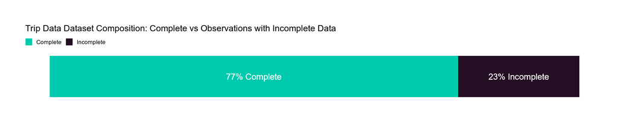

```r
plot_dataset_composition(
    df_observation_group_completeness,
    "Trip Data Dataset Composition: Complete vs Observations with Incomplete Data")
```

Getting the count of missing value by variable

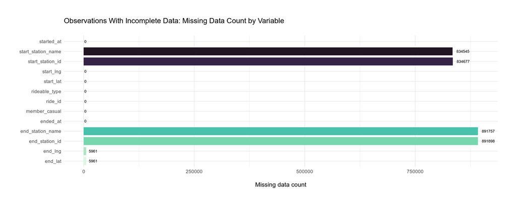

```r
options(repr.plot.width=20, repr.plot.height=8)

df_na_counts <- data.frame(
    variable = colnames(df),
    na_count = sapply(df, function(x) {sum(is.na(x))})) %>%
    as_tibble()

ggplot(data = df_na_counts, mapping = aes(x = na_count, y = variable, fill = variable)) +
    geom_col(width = 0.8, show.legend = FALSE) +
    labs(title = "\nObservations With Incomplete Data: Missing Data Count by Variable\n", x = "\nMissing data count") +
    geom_text(aes(label = na_count, hjust = -0.3)) +
    scale_fill_viridis(discrete = TRUE, direction = -1, option = "mako", alpha = 1) +
    theme_minimal(base_size = 17) +
    theme(
        plot.margin = margin(1,1.8,1.8,1.9, "cm"),
        axis.title.y = element_blank())
```

Exporting df to csv for further data preparation with python

```r
write.csv(df, "data/csv/divvy-tripdata-202206-202305-merged.csv", row.names = FALSE)
```

**Data preparation using python log**:

- Cleaned value formats
  - Removed the trailling ".0"s on station name
- Solved inconsistencies
  - Cleaned station ids with multiple station name
  - Removed observations with bad station id
- Addressed missing values
  - Matched station id with coordinates of existing observation

Importing dataset cleaned using python

```r
df <- as_tibble(read_csv("data/csv/divvy-tripdata-202206-202305-merged-cleaned.csv"))
```

```r
glimpse(df)
```

```
Rows: 4,943,103
Columns: 13
$ ride_id            <chr> "0AFDFDED87B18711", "73824977D6BA1702", "CF3DD3F4E1…
$ rideable_type      <chr> "electric_bike", "electric_bike", "electric_bike", …
$ started_at         <dttm> 2022-06-30 08:02:37, 2022-06-30 08:12:58, 2022-06-…
$ ended_at           <dttm> 2022-06-30 08:07:30, 2022-06-30 08:17:04, 2022-06-…
$ start_station_name <chr> "N Sheffield Ave & W Wellington Ave", "N Sheffield …
$ start_station_id   <chr> "20256", "20256", "1134", "932", "430", "428", "868…
$ end_station_name   <chr> "N Sheffield Ave & W Wellington Ave", "N Sheffield …
$ end_station_id     <chr> "20256", "20256", "1134", "430", "932", "428", "868…
$ start_lat          <dbl> 41.94000, 41.94000, 41.97000, 41.96000, 41.95000, 4…
$ start_lng          <dbl> -87.65000, -87.65000, -87.71000, -87.72000, -87.710…
$ end_lat            <dbl> 41.94000, 41.94000, 41.97000, 41.95000, 41.96000, 4…
$ end_lng            <dbl> -87.65000, -87.65000, -87.71000, -87.71000, -87.720…
$ member_casual      <chr> "casual", "casual", "casual", "casual", "casual", "…
```

Checking for the total number of observations with incomplete data again with the dataset being cleaned

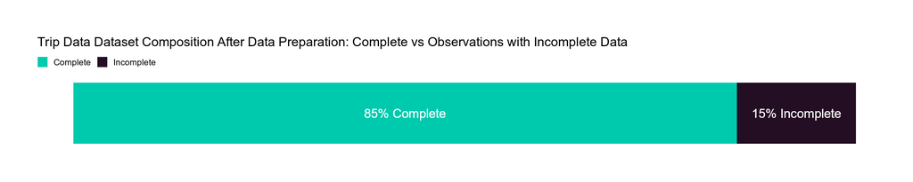

```r
total_count_complete_data <- nrow(df)
total_count_incomplete_data <- total_count_observations - total_count_complete_data

# Create data
df_observation_group_completeness <- data.frame(
    observation_group_label = c("Complete", "Incomplete"),
    value = c(total_count_complete_data, total_count_observations - total_count_complete_data))

# Reordering data
df_observation_group_completeness$observation_group_label <- factor(df_observation_group_completeness$observation_group_label, levels = c("Incomplete", "Complete"))

# Adding percentage and label columns
df_observation_group_completeness <- df_observation_group_completeness %>%
    mutate(percentage = percent(value / total_count_observations)) %>%
    mutate(plot_label = glue::glue("{percentage} {observation_group_label}"))

# Plotting data
plot_dataset_composition(
    df_observation_group_completeness,
    "Trip Data Dataset Composition After Data Preparation: Complete vs Observations with Incomplete Data")
```

Adding derived variable for analysis: trip duration in minutes

```r
df <- df %>%
    mutate(duration_in_minutes = round(difftime(ended_at, started_at, unit = "mins"), 1)) %>%
    select(append(colnames(df), 'duration_in_minutes', 4))
```

```r
df %>%
    arrange(duration_in_minutes) %>%
    head()
```

A tibble: 6 × 14

| ride_id <chr> | rideable_type <chr> | started_at <dttm> | ended_at <dttm> | duration_in_minutes <drtn> | start_station_name <chr> | start_station_id <chr> | end_station_name <chr> | end_station_id <chr> | start_lat <dbl> | start_lng <dbl> | end_lat <dbl> | end_lng <dbl> | member_casual <chr> |
| --- | --- | --- | --- | --- | --- | --- | --- | --- | --- | --- | --- | --- | --- |
| E137518FFE807752 | electric_bike | 2022-09-28 11:04:32 | 2022-09-21 06:31:11 | -10353.4 mins | Cornell Dr & Hayes Dr | 653 | Stony Island Ave & 63rd St | 653B | 41.78058 | -87.58517 | 41.78000 | -87.5900 | member |
| 918F745F62CAC29E | classic_bike | 2022-10-13 14:42:10 | 2022-10-13 11:53:28 | -168.7 mins | Wilton Ave & Diversey Pkwy* | chargingstx0 | Wilton Ave & Diversey Pkwy* | chargingstx0 | 41.93242 | -87.65270 | 41.93242 | -87.6527 | member |
| 38B9F148CE80499B | electric_bike | 2022-06-07 19:23:03 | 2022-06-07 17:05:38 | -137.4 mins | Narragansett & Wrightwood | 314 | Narragansett & Wrightwood | 314 | 41.93000 | -87.79000 | 41.93000 | -87.7900 | casual |
| BF114472ABA0289C | electric_bike | 2022-06-07 19:14:47 | 2022-06-07 17:05:42 | -129.1 mins | Base - 2132 W Hubbard | Hubbard Bike-checking (LBS-WH-TEST) | W Armitage Ave & N Sheffield Ave | 20254 | 41.91783 | -87.65336 | 41.92000 | -87.6500 | member |
| 072E947E156D142D | electric_bike | 2022-06-07 19:14:46 | 2022-06-07 17:07:45 | -127.0 mins | W Armitage Ave & N Sheffield Ave | 20254 | W Armitage Ave & N Sheffield Ave | 20254 | 41.92000 | -87.65000 | 41.92000 | -87.6500 | casual |
| BBD84670E05463A9 | electric_bike | 2022-06-07 19:11:33 | 2022-06-07 17:05:24 | -126.2 mins | Mozart Elementary School | 509 | Public Rack - Hamlin Ave & Fullerton Ave | 507 | 41.92000 | -87.72000 | 41.93000 | -87.7200 | casual |

Checking how many observations have trip duration in minutes in negative

```r
df %>%
    filter(duration_in_minutes < 0) %>%
    nrow()
```

85

Dropping observations where duration in minutes is in negative

```r
df <- filter(df, duration_in_minutes > 0)
```

```r
df %>%
    arrange(desc(duration_in_minutes)) %>%
    head()
```

A tibble: 6 × 14

| ride_id <chr> | rideable_type <chr> | started_at <dttm> | ended_at <dttm> | duration_in_minutes <drtn> | start_station_name <chr> | start_station_id <chr> | end_station_name <chr> | end_station_id <chr> | start_lat <dbl> | start_lng <dbl> | end_lat <dbl> | end_lng <dbl> | member_casual <chr> |
| --- | --- | --- | --- | --- | --- | --- | --- | --- | --- | --- | --- | --- | --- |
| DC510E6F98003A94 | docked_bike | 2022-07-04 18:37:11 | 2022-07-27 00:32:38 | 32035.4 mins | DuSable Lake Shore Dr & Monroe St | 13300 | Green St & Randolph St* | chargingstx3 | 41.88096 | -87.61674 | 41.88360 | -87.64863 | casual |
| 59AD7EE868FC6588 | docked_bike | 2023-05-30 12:48:08 | 2023-06-07 23:04:26 | 12136.3 mins | Wells St & Polk St | SL-011 | Lincoln Ave & Roscoe St* | chargingstx5 | 41.87273 | -87.63352 | 41.94335 | -87.67067 | casual |
| E5886B2D636415DF | docked_bike | 2022-07-10 18:52:42 | 2022-07-18 06:59:55 | 10807.2 mins | DuSable Lake Shore Dr & Monroe St | 13300 | Bissell St & Armitage Ave* | chargingstx1 | 41.88096 | -87.61674 | 41.91830 | -87.65218 | casual |
| 17405F31D17313B2 | docked_bike | 2022-07-22 13:07:51 | 2022-07-29 11:10:12 | 9962.4 mins | Dusable Harbor | KA1503000064 | Green St & Randolph St* | chargingstx3 | 41.88698 | -87.61281 | 41.88360 | -87.64863 | casual |
| B139FE7DF42819B0 | docked_bike | 2022-10-24 14:37:54 | 2022-10-30 08:01:42 | 8243.8 mins | Field Museum | 13029 | Bissell St & Armitage Ave* | chargingstx1 | 41.86531 | -87.61787 | 41.91830 | -87.65218 | casual |
| 23B687E80DE52ED8 | docked_bike | 2022-06-18 20:25:31 | 2022-06-23 11:38:23 | 6672.9 mins | California Ave & Division St | 13256 | Morgan St & Lake St* | chargingstx4 | 41.90303 | -87.69747 | 41.88549 | -87.65229 | casual |

Adding derived variable for analysis: weekday

```r
df <- df %>%
    mutate(weekday = wday(started_at, label = TRUE, abbr = FALSE, week_start = 1)) %>%
    select(append(colnames(df), 'weekday', 4))
```

```r
head(df)
```

A tibble: 6 × 15

| ride_id <chr> | rideable_type <chr> | started_at <dttm> | ended_at <dttm> | weekday <ord> | duration_in_minutes <drtn> | start_station_name <chr> | start_station_id <chr> | end_station_name <chr> | end_station_id <chr> | start_lat <dbl> | start_lng <dbl> | end_lat <dbl> | end_lng <dbl> | member_casual <chr> |
| --- | --- | --- | --- | --- | --- | --- | --- | --- | --- | --- | --- | --- | --- | --- |
| 0AFDFDED87B18711 | electric_bike | 2022-06-30 08:02:37 | 2022-06-30 08:07:30 | Thursday | 4.9 mins | N Sheffield Ave & W Wellington Ave | 20256 | N Sheffield Ave & W Wellington Ave | 20256 | 41.94 | -87.65 | 41.94 | -87.65 | casual |
| 73824977D6BA1702 | electric_bike | 2022-06-30 08:12:58 | 2022-06-30 08:17:04 | Thursday | 4.1 mins | N Sheffield Ave & W Wellington Ave | 20256 | N Sheffield Ave & W Wellington Ave | 20256 | 41.94 | -87.65 | 41.94 | -87.65 | casual |
| CF3DD3F4E16263F7 | electric_bike | 2022-06-30 18:42:45 | 2022-06-30 19:04:26 | Thursday | 21.7 mins | Public Rack - Kimball Ave & Lawrence Ave | 1134 | Public Rack - Kimball Ave & Lawrence Ave | 1134 | 41.97 | -87.71 | 41.97 | -87.71 | casual |
| 54D832624A983D4C | electric_bike | 2022-06-30 15:07:51 | 2022-06-30 15:12:28 | Thursday | 4.6 mins | Public Rack - Jensen Park | 932 | Troy St & Grace St | 430 | 41.96 | -87.72 | 41.95 | -87.71 | casual |
| F6D59CBDC2418088 | electric_bike | 2022-06-30 13:42:32 | 2022-06-30 14:12:23 | Thursday | 29.9 mins | Troy St & Grace St | 430 | Public Rack - Jensen Park | 932 | 41.95 | -87.71 | 41.96 | -87.72 | casual |
| 93C0C755C501F153 | electric_bike | 2022-06-30 01:23:24 | 2022-06-30 01:35:03 | Thursday | 11.7 mins | Milwaukee Ave & Fullerton Ave | 428 | Milwaukee Ave & Fullerton Ave | 428 | 41.92 | -87.70 | 41.92 | -87.70 | casual |

Adding derived variable for analysis: month

```r
df <- df %>%
    mutate(month = month(started_at, label = TRUE, abbr = FALSE)) %>%
    select(append(colnames(df), 'month', 4))
```

```r
head(df)
```

A tibble: 6 × 16

| ride_id <chr> | rideable_type <chr> | started_at <dttm> | ended_at <dttm> | month <ord> | weekday <ord> | duration_in_minutes <drtn> | start_station_name <chr> | start_station_id <chr> | end_station_name <chr> | end_station_id <chr> | start_lat <dbl> | start_lng <dbl> | end_lat <dbl> | end_lng <dbl> | member_casual <chr> |
| --- | --- | --- | --- | --- | --- | --- | --- | --- | --- | --- | --- | --- | --- | --- | --- |
| 0AFDFDED87B18711 | electric_bike | 2022-06-30 08:02:37 | 2022-06-30 08:07:30 | June | Thursday | 4.9 mins | N Sheffield Ave & W Wellington Ave | 20256 | N Sheffield Ave & W Wellington Ave | 20256 | 41.94 | -87.65 | 41.94 | -87.65 | casual |
| 73824977D6BA1702 | electric_bike | 2022-06-30 08:12:58 | 2022-06-30 08:17:04 | June | Thursday | 4.1 mins | N Sheffield Ave & W Wellington Ave | 20256 | N Sheffield Ave & W Wellington Ave | 20256 | 41.94 | -87.65 | 41.94 | -87.65 | casual |
| CF3DD3F4E16263F7 | electric_bike | 2022-06-30 18:42:45 | 2022-06-30 19:04:26 | June | Thursday | 21.7 mins | Public Rack - Kimball Ave & Lawrence Ave | 1134 | Public Rack - Kimball Ave & Lawrence Ave | 1134 | 41.97 | -87.71 | 41.97 | -87.71 | casual |
| 54D832624A983D4C | electric_bike | 2022-06-30 15:07:51 | 2022-06-30 15:12:28 | June | Thursday | 4.6 mins | Public Rack - Jensen Park | 932 | Troy St & Grace St | 430 | 41.96 | -87.72 | 41.95 | -87.71 | casual |
| F6D59CBDC2418088 | electric_bike | 2022-06-30 13:42:32 | 2022-06-30 14:12:23 | June | Thursday | 29.9 mins | Troy St & Grace St | 430 | Public Rack - Jensen Park | 932 | 41.95 | -87.71 | 41.96 | -87.72 | casual |
| 93C0C755C501F153 | electric_bike | 2022-06-30 01:23:24 | 2022-06-30 01:35:03 | June | Thursday | 11.7 mins | Milwaukee Ave & Fullerton Ave | 428 | Milwaukee Ave & Fullerton Ave | 428 | 41.92 | -87.70 | 41.92 | -87.70 | casual |

Adding derived variable for analysis: season

```r
# Making a function to get season from numeric representation of a month
get_season <- function(datetime) {
    month_numeric <- month(datetime)

    if (month_numeric %in% c(3:5)){
        return("Spring")
    } else if (month_numeric %in% c(6:8)) {
        return("Summer")
    } else if (month_numeric %in% c(9:11)) {
        return("Autumn")
    } else {
        return("Winter")
    }
}
```

```r
df <- df %>%
    mutate(season = sapply(started_at, get_season)) %>%
    select(append(colnames(df), 'season', 4))
```

```r
head(df)
```

A tibble: 6 × 17

| ride_id <chr> | rideable_type <chr> | started_at <dttm> | ended_at <dttm> | season <chr> | month <ord> | weekday <ord> | duration_in_minutes <drtn> | start_station_name <chr> | start_station_id <chr> | end_station_name <chr> | end_station_id <chr> | start_lat <dbl> | start_lng <dbl> | end_lat <dbl> | end_lng <dbl> | member_casual <chr> |
| --- | --- | --- | --- | --- | --- | --- | --- | --- | --- | --- | --- | --- | --- | --- | --- | --- |
| 0AFDFDED87B18711 | electric_bike | 2022-06-30 08:02:37 | 2022-06-30 08:07:30 | Summer | June | Thursday | 4.9 mins | N Sheffield Ave & W Wellington Ave | 20256 | N Sheffield Ave & W Wellington Ave | 20256 | 41.94 | -87.65 | 41.94 | -87.65 | casual |
| 73824977D6BA1702 | electric_bike | 2022-06-30 08:12:58 | 2022-06-30 08:17:04 | Summer | June | Thursday | 4.1 mins | N Sheffield Ave & W Wellington Ave | 20256 | N Sheffield Ave & W Wellington Ave | 20256 | 41.94 | -87.65 | 41.94 | -87.65 | casual |
| CF3DD3F4E16263F7 | electric_bike | 2022-06-30 18:42:45 | 2022-06-30 19:04:26 | Summer | June | Thursday | 21.7 mins | Public Rack - Kimball Ave & Lawrence Ave | 1134 | Public Rack - Kimball Ave & Lawrence Ave | 1134 | 41.97 | -87.71 | 41.97 | -87.71 | casual |
| 54D832624A983D4C | electric_bike | 2022-06-30 15:07:51 | 2022-06-30 15:12:28 | Summer | June | Thursday | 4.6 mins | Public Rack - Jensen Park | 932 | Troy St & Grace St | 430 | 41.96 | -87.72 | 41.95 | -87.71 | casual |
| F6D59CBDC2418088 | electric_bike | 2022-06-30 13:42:32 | 2022-06-30 14:12:23 | Summer | June | Thursday | 29.9 mins | Troy St & Grace St | 430 | Public Rack - Jensen Park | 932 | 41.95 | -87.71 | 41.96 | -87.72 | casual |
| 93C0C755C501F153 | electric_bike | 2022-06-30 01:23:24 | 2022-06-30 01:35:03 | Summer | June | Thursday | 11.7 mins | Milwaukee Ave & Fullerton Ave | 428 | Milwaukee Ave & Fullerton Ave | 428 | 41.92 | -87.70 | 41.92 | -87.70 | casual |

Adding derived variable for analysis: distance

```r
get_distance_traveled_meters <- function(observation) {
    longitude_1 <- observation[2]
    latitude_1 <- observation[1]
    longitude_2 <- observation[4]
    latitude_2 <- observation[3]

    distance_in_meters <- round(pluck(distm(
        c(longitude_1, latitude_1),
        c(longitude_2, latitude_2)),
    1), 2)

    distance_in_meters
}
```

```r
df <- df %>%
    mutate(distance_traveled_m = apply(
        as.matrix(select(df, start_lat, start_lng, end_lat, end_lng)),
        MARGIN = 1, FUN = get_distance_traveled_meters)) %>%
    select(append(colnames(df), 'distance_traveled_m', 8))
```

```r
head(df)
```

A tibble: 6 × 18

| ride_id <chr> | rideable_type <chr> | started_at <dttm> | ended_at <dttm> | season <chr> | month <ord> | weekday <ord> | duration_in_minutes <drtn> | distance_traveled_m <dbl> | start_station_name <chr> | start_station_id <chr> | end_station_name <chr> | end_station_id <chr> | start_lat <dbl> | start_lng <dbl> | end_lat <dbl> | end_lng <dbl> | member_casual <chr> |
| --- | --- | --- | --- | --- | --- | --- | --- | --- | --- | --- | --- | --- | --- | --- | --- | --- | --- |
| 0AFDFDED87B18711 | electric_bike | 2022-06-30 08:02:37 | 2022-06-30 08:07:30 | Summer | June | Thursday | 4.9 mins | 0.00 | N Sheffield Ave & W Wellington Ave | 20256 | N Sheffield Ave & W Wellington Ave | 20256 | 41.94 | -87.65 | 41.94 | -87.65 | casual |
| 73824977D6BA1702 | electric_bike | 2022-06-30 08:12:58 | 2022-06-30 08:17:04 | Summer | June | Thursday | 4.1 mins | 0.00 | N Sheffield Ave & W Wellington Ave | 20256 | N Sheffield Ave & W Wellington Ave | 20256 | 41.94 | -87.65 | 41.94 | -87.65 | casual |
| CF3DD3F4E16263F7 | electric_bike | 2022-06-30 18:42:45 | 2022-06-30 19:04:26 | Summer | June | Thursday | 21.7 mins | 0.00 | Public Rack - Kimball Ave & Lawrence Ave | 1134 | Public Rack - Kimball Ave & Lawrence Ave | 1134 | 41.97 | -87.71 | 41.97 | -87.71 | casual |
| 54D832624A983D4C | electric_bike | 2022-06-30 15:07:51 | 2022-06-30 15:12:28 | Summer | June | Thursday | 4.6 mins | 1386.04 | Public Rack - Jensen Park | 932 | Troy St & Grace St | 430 | 41.96 | -87.72 | 41.95 | -87.71 | casual |
| F6D59CBDC2418088 | electric_bike | 2022-06-30 13:42:32 | 2022-06-30 14:12:23 | Summer | June | Thursday | 29.9 mins | 1386.04 | Troy St & Grace St | 430 | Public Rack - Jensen Park | 932 | 41.95 | -87.71 | 41.96 | -87.72 | casual |
| 93C0C755C501F153 | electric_bike | 2022-06-30 01:23:24 | 2022-06-30 01:35:03 | Summer | June | Thursday | 11.7 mins | 0.00 | Milwaukee Ave & Fullerton Ave | 428 | Milwaukee Ave & Fullerton Ave | 428 | 41.92 | -87.70 | 41.92 | -87.70 | casual |

```r
glimpse(df)
```

```
Rows: 4,934,037
Columns: 18
$ ride_id             <chr> "0AFDFDED87B18711", "73824977D6BA1702", "CF3DD3F4E…
$ rideable_type       <chr> "electric_bike", "electric_bike", "electric_bike",…
$ started_at          <dttm> 2022-06-30 08:02:37, 2022-06-30 08:12:58, 2022-06…
$ ended_at            <dttm> 2022-06-30 08:07:30, 2022-06-30 08:17:04, 2022-06…
$ season              <chr> "Summer", "Summer", "Summer", "Summer", "Summer", …
$ month               <ord> June, June, June, June, June, June, June, June, Ju…
$ weekday             <ord> Thursday, Thursday, Thursday, Thursday, Thursday, …
$ duration_in_minutes <drtn> 4.9 mins, 4.1 mins, 21.7 mins, 4.6 mins, 29.9 min…
$ distance_traveled_m <dbl> 0.00, 0.00, 0.00, 1386.04, 1386.04, 0.00, 0.00, 33…
$ start_station_name  <chr> "N Sheffield Ave & W Wellington Ave", "N Sheffield…
$ start_station_id    <chr> "20256", "20256", "1134", "932", "430", "428", "86…
$ end_station_name    <chr> "N Sheffield Ave & W Wellington Ave", "N Sheffield…
$ end_station_id      <chr> "20256", "20256", "1134", "430", "932", "428", "86…
$ start_lat           <dbl> 41.94000, 41.94000, 41.97000, 41.96000, 41.95000, …
$ start_lng           <dbl> -87.65000, -87.65000, -87.71000, -87.72000, -87.71…
$ end_lat             <dbl> 41.94000, 41.94000, 41.97000, 41.95000, 41.96000, …
$ end_lng             <dbl> -87.65000, -87.65000, -87.71000, -87.71000, -87.72…
$ member_casual       <chr> "casual", "casual", "casual", "casual", "casual", …
```

### 4. Analyzing data to find patterns, relationships, and trends

#### Conducting differentiation of usage patterns

Determining the differences in usage patterns between casual pass users and annual members. Identifying peak usage times, popular docking stations, bike use durations, and other relevant factors that influence customers' preferences.

Determining the bike trip value counts between the user groups (casual pass user vs annual member).

```r
df_bike_trip_value_count_by_user_type <- df %>%
    select(member_casual) %>%
    table() %>%
    as_tibble() %>%
    setNames(c("user_type", "count")) %>%
    mutate(fraction_from_population = percent(count / nrow(df)))

df_bike_trip_value_count_by_user_type
```

A tibble: 2 × 3

| user_type <chr> | count <int> | fraction_from_population <chr> |
| --- | --- | --- |
| casual | 1939869 | 39% |
| member | 2994168 | 61% |

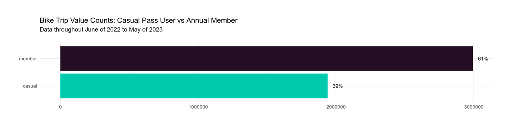

```r
options(repr.plot.width=20, repr.plot.height=5)

ggplot(data = df_bike_trip_value_count_by_user_type, mapping = aes(x = count, y = user_type, fill = user_type)) +
    geom_col(show.legend = FALSE) +
    labs(
        title = "\nBike Trip Value Counts: Casual Pass User vs Annual Member",
        subtitle = "Data throughout June of 2022 to May of 2023\n") +
    geom_text(aes(label = fraction_from_population, hjust = -0.5), size = 5) +
    scale_fill_manual(values = c("#00caad", "#240e23")) +
    theme_minimal(base_size = 17) +
    theme(
        plot.margin = margin(1,1.8,1.8,1.9, "cm"),
        axis.title.y = element_blank(),
        axis.title.x = element_blank())
```

Determining the rideable type usage counts between the user groups (casual pass user vs annual member).

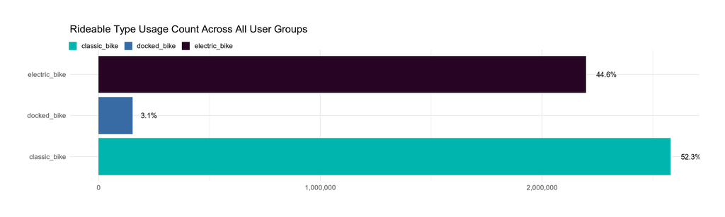

```r
options(repr.plot.width=20, repr.plot.height=6)

df %>%
    ggplot(mapping = aes(y = rideable_type)) +
    labs(title = "\nRideable Type Usage Count Across All User Groups\n") +
    geom_histogram(
        mapping = aes(x = after_stat(count), fill = rideable_type),
        stat = "count") +
    geom_text(
        mapping = aes(
            x = after_stat(count), y = rideable_type,
            label = percent(after_stat(count) / nrow(df)),
            hjust = -0.5),
        stat = "count",
        size = 5) +
    scale_fill_manual(values = c("#00b5ae", "#386ba4", "#280424")) +
    scale_x_continuous(label = comma) +
    theme_minimal(base_size = 17) +
    theme(
        plot.margin = margin(1.,1.8,1.8,1.9, "cm"),
        axis.title.y = element_blank(), axis.title.x = element_blank(),
        legend.position = c(0.126, 1.03), legend.title = element_blank(),
        legend.direction = "horizontal", )
```

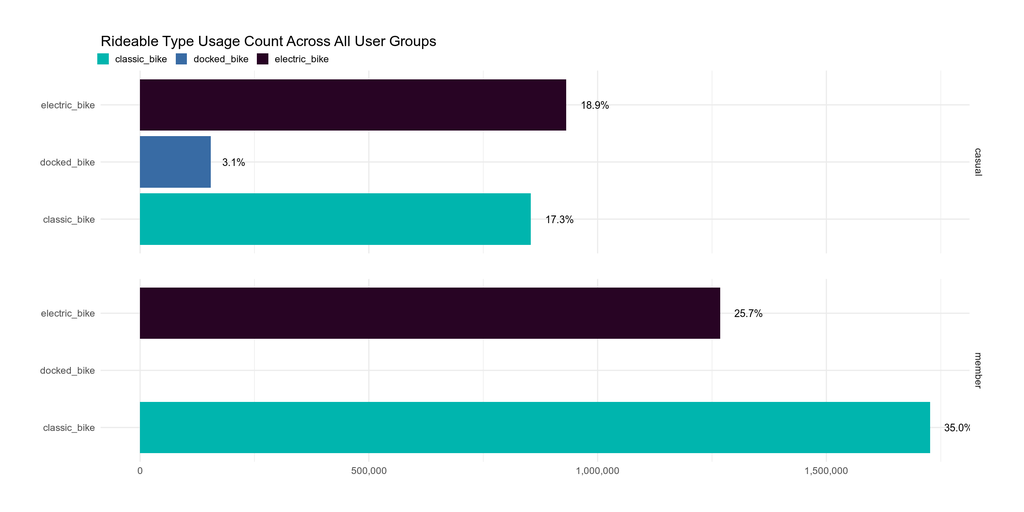

```r
options(repr.plot.width=20, repr.plot.height=10)

df %>%
    ggplot(mapping = aes(y = rideable_type)) +
    labs(title = "\nRideable Type Usage Count Across All User Groups\n") +
    geom_histogram(
        mapping = aes(x = after_stat(count), fill = rideable_type),
        stat = "count") +
    geom_text(
        mapping = aes(
            x = after_stat(count), y = rideable_type,
            label = percent(after_stat(count) / nrow(df)),
            hjust = -0.5),
        stat = "count", size = 5) +
    scale_fill_manual(values = c("#00b5ae", "#386ba4", "#280424")) +
    scale_x_continuous(label = comma) +
    facet_grid(rows = vars(member_casual)) +
    theme_minimal(base_size = 17) +
    theme(
        plot.margin = margin(1,1.8,1.8,1.9, "cm"),
        axis.title.y = element_blank(), axis.title.x = element_blank(),
        legend.position = c(0.127, 1.03), legend.title = element_blank(),
        legend.direction = "horizontal", panel.spacing = unit(2.5, "lines"))
```

Determining the differences between the user groups with time as a factor. Particularly, differences between weekdays, months, seasons.

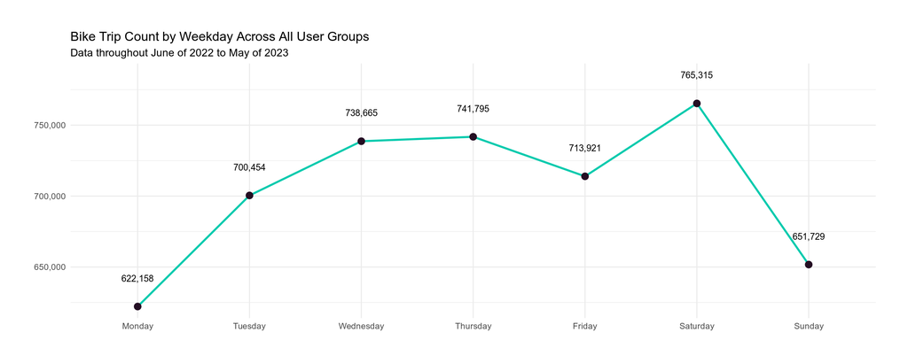

```r
options(repr.plot.width=20, repr.plot.height=8)

df %>%
    ggplot(aes(x = weekday)) +
    labs(
        title = "\nBike Trip Count by Weekday Across All User Groups",
        subtitle = "Data throughout June of 2022 to May of 2023") +
    geom_line(
        mapping = aes(x = weekday, group = 1),
        stat = "count", linewidth = 1.5, color = "#00caad") +
    geom_point(
        mapping = aes(x = weekday, group = 1),
        stat = "count", color = "#240e23", size = 5) +
    geom_text(
        mapping = aes(label = scales::comma(after_stat(count)), x = weekday, y = after_stat(count) + 20000),
        size = 5, stat = "count") +
    scale_y_continuous(label = comma) +
    theme_minimal(base_size = 17) +
    theme(
        plot.margin = margin(1,1.8,1.8,1.9, "cm"),
        axis.title.y = element_blank(),
        axis.title.x = element_blank())
```

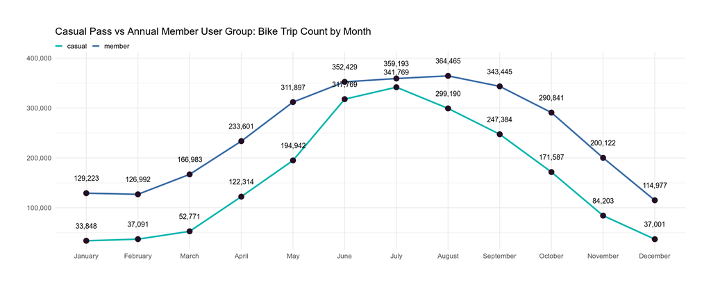

```r
options(repr.plot.width=20, repr.plot.height=8)

df %>%
    ggplot(aes(x = month)) +
    labs(title = "\nCasual Pass vs Annual Member User Group: Bike Trip Count by Month\n") +
    geom_line(
        mapping = aes(x = month, group = member_casual, color = member_casual),
        stat = "count", linewidth = 1.5) +
    geom_point(
        mapping = aes(x = month, group = member_casual),
        stat = "count", color = "#240e23", size = 5) +
    geom_text(
        mapping = aes(
            label = scales::comma(after_stat(count)),
            x = month, y = after_stat(count) + 30000,
            group = member_casual),
        size = 5, stat = "count") +
    scale_y_continuous(label = comma) +
    scale_color_manual(values = c("#00b5ae", "#386ba4")) +
    theme_minimal(base_size = 17) +
    theme(
        plot.margin = margin(1.2,1.8,1.8,1.9, "cm"),
        axis.title.y = element_blank(), axis.title.x = element_blank(),
        legend.position = c(0.055, 1.03), legend.title = element_blank(),
        legend.direction = "horizontal", )
```

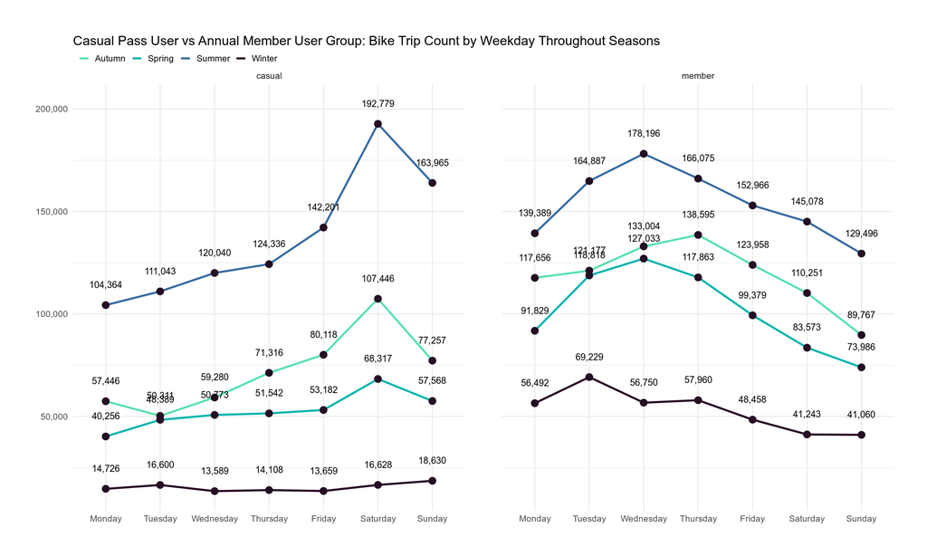

```r
options(repr.plot.width=20, repr.plot.height=12)

df %>%
    ggplot(aes(x = weekday)) +
    labs(title = "\nCasual Pass User vs Annual Member User Group: Bike Trip Count by Weekday Throughout Seasons\n") +
    geom_line(
        mapping = aes(x = weekday, group = season, color = season),
        stat = "count", linewidth = 1.5) +
    geom_point(
        mapping = aes(x = weekday, group = season),
        stat = "count", color = "#240e23", size = 5) +
    geom_text(
        mapping = aes(label = scales::comma(after_stat(count)), x = weekday, y = after_stat(count) + 10000, group = season),
        size = 5, stat = "count") +
    scale_y_continuous(label = comma) +
    scale_color_manual(values = c("#58e2ad", "#00b5ae", "#386ba4", "#280424")) +
    facet_grid(cols = vars(member_casual)) +
    theme_minimal(base_size = 17) +
    theme(
        plot.margin = margin(1.2,1.8,1.8,1.9, "cm"),
        axis.title.y = element_blank(), axis.title.x = element_blank(),
        legend.position = c(0.125, 1.06), legend.title = element_blank(),
        legend.direction = "horizontal", panel.spacing = unit(4, "lines"))
```

Determining the differences on bike use duration between user groups and how long the trip duration of most the users are

```r
get_mode <- function(df) {
    mode <- df %>%
        table() %>%
        as_tibble() %>%
        arrange(desc(n)) %>%
        pluck(1, 1) %>%
        as.double()

    return(mode)
}
```

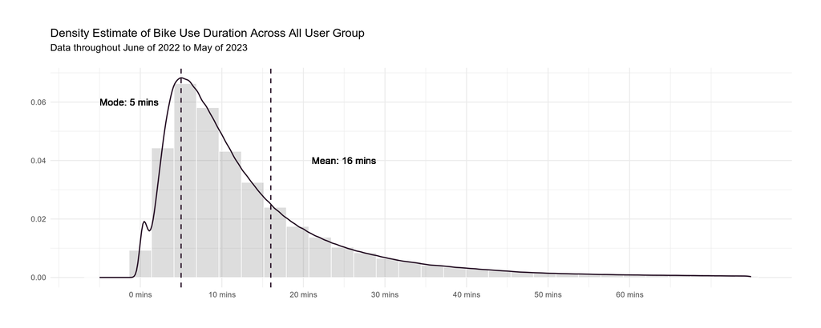

```r
options(repr.plot.width=20, repr.plot.height=8)

mode_duration_in_minutes_across_all_users <- df %>%
    mutate(duration_in_minutes = as.double(duration_in_minutes)) %>%
    # filter(duration_in_minutes < 75) %>%
    pull(duration_in_minutes) %>%
    get_mode()

mean_duration_in_minutes_across_all_users <- df %>%
    mutate(duration_in_minutes = as.double(duration_in_minutes)) %>%
    # filter(duration_in_minutes < 75) %>%
    pull(duration_in_minutes) %>%
    mean() %>%
    round(1)

df %>%
    mutate(duration_in_minutes = as.double(duration_in_minutes)) %>%
    filter(duration_in_minutes < 75) %>%
    ggplot(aes(x = duration_in_minutes)) +
        labs(
            title = "\nDensity Estimate of Bike Use Duration Across All User Group",
            subtitle = "Data throughout June of 2022 to May of 2023\n")+
        geom_histogram(
            mapping = aes(y = after_stat(density)),
            position = "identity", color = "white", alpha = 0.2) +
        geom_density(color = "#240e23", linewidth = 1) +
        geom_vline(
            mapping = aes(xintercept = mode_duration_in_minutes_across_all_users),
            linewidth = 1, linetype = "dashed", color = "#240e23") +
        geom_text(
            mapping = aes(x = - 5, y = 0.06),
            label = glue::glue("Mode: {mode_duration_in_minutes_across_all_users} mins"),
            size = 6, hjust = "left") +
        geom_vline(
            mapping = aes(xintercept = mean_duration_in_minutes_across_all_users),
            linewidth = 1, linetype = "dashed", color = "#240e23") +
        geom_text(
            mapping = aes(x = mean_duration_in_minutes_across_all_users + 5, y = 0.04),
            label = glue::glue("Mean: {mean_duration_in_minutes_across_all_users} mins"),
            size = 6, hjust = "left") +
        scale_x_continuous(
            breaks = c(0, 10, 20, 30, 40, 50, 60),
            labels = sapply(c(0, 10, 20, 30, 40, 50, 60), FUN = function(x) {glue::glue("{x} mins")})) +
        theme_minimal(base_size = 17) +
        theme(
            plot.margin = margin(1,1.8,1.8,1.9, "cm"),
            axis.title.y = element_blank(),
            axis.title.x = element_blank())
```

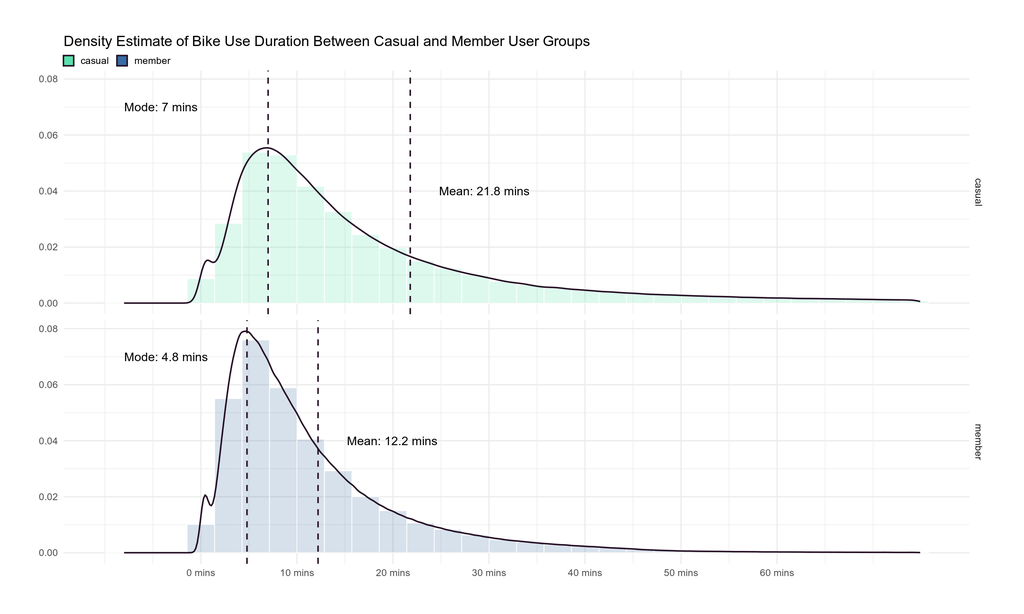

```r
options(repr.plot.width=20, repr.plot.height=12)

df_duration_minutes_member_casual_group_mode <- df %>%
    mutate(duration_in_minutes = as.double(duration_in_minutes)) %>%
    # filter(duration_in_minutes < 75) %>%
    group_by(member_casual) %>%
    summarize(mode = get_mode(duration_in_minutes)) %>%
    setNames(c("member_casual", "user_group_mode")) %>%
    mutate(plot_label = glue::glue("Mode: {user_group_mode} mins"))

df_duration_minutes_member_casual_group_mean <- df %>%
    mutate(duration_in_minutes = as.double(duration_in_minutes)) %>%
    # filter(duration_in_minutes < 75) %>%
    group_by(member_casual) %>%
    summarize(mean_duration = round(mean(duration_in_minutes), 1)) %>%
    setNames(c("member_casual", "user_group_mean")) %>%
    mutate(plot_label = glue::glue("Mean: {user_group_mean} mins"))

df %>%
    mutate(duration_in_minutes = as.double(duration_in_minutes)) %>%
    filter(duration_in_minutes < 75) %>%
    ggplot(aes(x = duration_in_minutes)) +
        labs(
            title = "\nDensity Estimate of Bike Use Duration Between Casual and Member User Groups\n") +
        geom_histogram(
            mapping = aes(y = after_stat(density), fill = member_casual),
            position = "identity", color = "white", alpha = 0.2) +
        geom_density(color = "#240e23", linewidth = 1) +
        geom_vline(
            data = df_duration_minutes_member_casual_group_mode,
            mapping = aes(xintercept = user_group_mode),
            linewidth = 1, linetype = "dashed", color = "#240e23") +
        geom_text(
            data = df_duration_minutes_member_casual_group_mode,
            mapping = aes(x = -8, y = 0.07, label = plot_label),
            size = 6, hjust = "left") +
        geom_vline(
            data = df_duration_minutes_member_casual_group_mean,
            mapping = aes(xintercept = user_group_mean),
            linewidth = 1, linetype = "dashed", color = "#240e23") +
        geom_text(
            data = df_duration_minutes_member_casual_group_mean,
            mapping = aes(x = user_group_mean + 3, y = 0.04, label = plot_label),
            size = 6, hjust = "left") +
        facet_grid(rows = vars(member_casual)) +
        scale_x_continuous(
            breaks = c(0, 10, 20, 30, 40, 50, 60),
            labels = sapply(c(0, 10, 20, 30, 40, 50, 60), FUN = function(x) {glue::glue("{x} mins")})) +
        scale_fill_manual(values = c("#58e2ad", "#386ba4")) +
        theme_minimal(base_size = 17) +
        theme(
            plot.margin = margin(1,1.8,1.8,1.9, "cm"),
            axis.title.y = element_blank(), axis.title.x = element_blank(),
            legend.position = c(0.055, 1.02), legend.title = element_blank(), legend.direction = "horizontal")
```

Determining the differences with distance traveled from start station to end station as a factor between user groups and how far most users travel

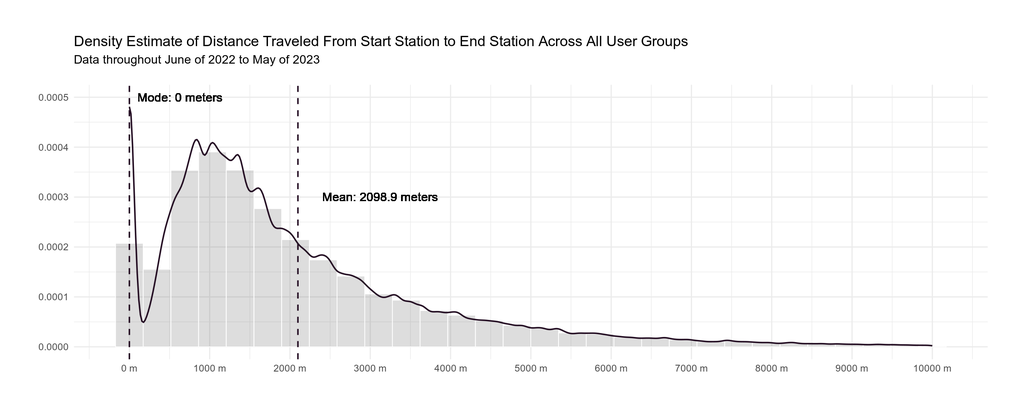

```r
options(repr.plot.width=20, repr.plot.height=8)

mode_distance_traveled_across_all_users <- df %>%
    # filter(distance_traveled_m < 10000) %>%
    pull(distance_traveled_m) %>%
    get_mode()

mean_distance_traveled_across_all_users <- df %>%
    # filter(distance_traveled_m < 10000) %>%
    pull(distance_traveled_m) %>%
    mean() %>%
    round(1)

df %>%
    filter(distance_traveled_m < 10000) %>%
    ggplot(aes(x = distance_traveled_m)) +
        labs(
            title = "\nDensity Estimate of Distance Traveled From Start Station to End Station Across All User Groups",
            subtitle = "Data throughout June of 2022 to May of 2023\n")+
        geom_histogram(
            mapping = aes(y = after_stat(density)),
            position = "identity", color = "white", alpha = 0.2) +
        geom_density(color = "#240e23", linewidth = 1) +
        geom_vline(
            mapping = aes(xintercept = mode_distance_traveled_across_all_users),
            linewidth = 1, linetype = "dashed", color = "#240e23") +
        geom_text(
            mapping = aes(x = 100, y = 0.0005),
            label = glue::glue("Mode: {mode_distance_traveled_across_all_users} meters"),
            size = 6, hjust = "left") +
        geom_vline(
            mapping = aes(xintercept = mean_distance_traveled_across_all_users),
            linewidth = 1, linetype = "dashed", color = "#240e23") +
        geom_text(
            mapping = aes(x = mean_distance_traveled_across_all_users + 300, y = 0.0003),
            label = glue::glue("Mean: {mean_distance_traveled_across_all_users} meters"),
            size = 6, hjust = "left") +
        scale_x_continuous(
            breaks = seq(0, 10000, 1000),
            labels = sapply(seq(0, 10000, 1000), FUN = function(x) {glue::glue("{x} m")})) +
        theme_minimal(base_size = 17) +
        theme(
            plot.margin = margin(1,1.8,1.8,1.9, "cm"),
            axis.title.y = element_blank(),
            axis.title.x = element_blank())
```

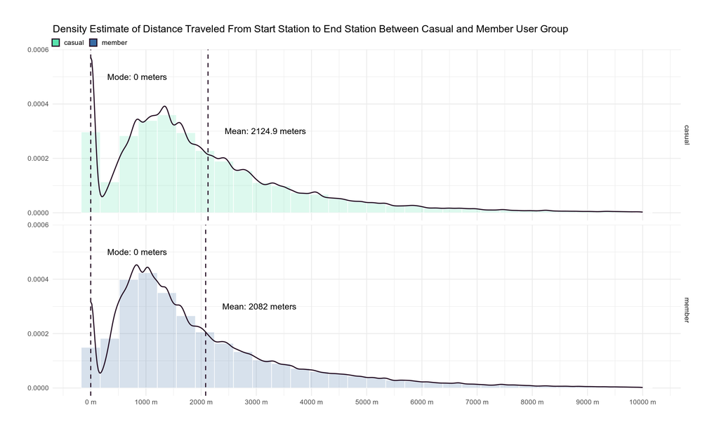

```r
options(repr.plot.width=20, repr.plot.height=12)

df_distance_traveled_member_casual_group_mode <- df %>%
    # filter(distance_traveled_m < 10000) %>%
    group_by(member_casual) %>%
    summarize(mode = get_mode(distance_traveled_m)) %>%
    setNames(c("member_casual", "user_group_mode")) %>%
    mutate(plot_label = glue::glue("Mode: {user_group_mode} meters"))

df_distance_traveled_member_casual_group_mean <- df %>%
    # filter(distance_traveled_m < 10000) %>%
    group_by(member_casual) %>%
    summarize(mean_distance = round(mean(distance_traveled_m), 1)) %>%
    setNames(c("member_casual", "user_group_mean")) %>%
    mutate(plot_label = glue::glue("Mean: {user_group_mean} meters"))

df %>%
    filter(distance_traveled_m < 10000) %>%
    ggplot(aes(x = distance_traveled_m)) +
        labs(
            title = "\nDensity Estimate of Distance Traveled From Start Station to End Station Between Casual and Member User Group\n")+
        geom_histogram(
            mapping = aes(y = after_stat(density), fill = member_casual),
            position = "identity", color = "white", alpha = 0.2) +
        geom_density(color = "#240e23", linewidth = 1) +
        geom_vline(
            data = df_distance_traveled_member_casual_group_mode,
            mapping = aes(xintercept = user_group_mode),
            linewidth = 1, linetype = "dashed", color = "#240e23") +
        geom_text(
            data = df_distance_traveled_member_casual_group_mode,
            mapping = aes(x = user_group_mode + 300, y = 0.0005, label = plot_label),
            size = 6, hjust = "left") +
        geom_vline(
            data = df_distance_traveled_member_casual_group_mean,
            mapping = aes(xintercept = user_group_mean),
            linewidth = 1, linetype = "dashed", color = "#240e23") +
        geom_text(
            data = df_distance_traveled_member_casual_group_mean,
            mapping = aes(x = user_group_mean + 300, y = 0.0003, label = plot_label),
            size = 6, hjust = "left") +
        scale_x_continuous(
            breaks = seq(0, 10000, 1000),
            labels = sapply(seq(0, 10000, 1000), FUN = function(x) {glue::glue("{x} m")})) +
        scale_fill_manual(values = c("#58e2ad", "#386ba4")) +
        facet_grid(rows = vars(member_casual)) +
        theme_minimal(base_size = 17) +
        theme(
            plot.margin = margin(1,1.8,1.8,1.9, "cm"),
            axis.title.y = element_blank(), axis.title.x = element_blank(),
            legend.position = c(0.055, 1.02), legend.title = element_blank(), legend.direction = "horizontal")
```

Determining the popular docking stations across all user groups

```r
plot_popular_station <- function(x, y, title) {
    options(repr.plot.width=20, repr.plot.height=7)

    ggplot(mapping = aes(y = fct_reorder(y, x), x = x, fill = y)) +
        geom_col(show.legend = FALSE) +
        labs(title = paste("\n", glue::glue("{title}") ,"\n")) +
        geom_text(aes(label = x, hjust = -0.5), size = 4.3) +
        scale_fill_viridis(discrete = TRUE, direction = 1, option = "mako", alpha = 1) +
        theme_minimal(base_size = 17) +
        theme(
            plot.margin = margin(1,3,1.8,1.9, "cm"),
            axis.title.y = element_blank(),
            axis.title.x = element_blank())
}
```

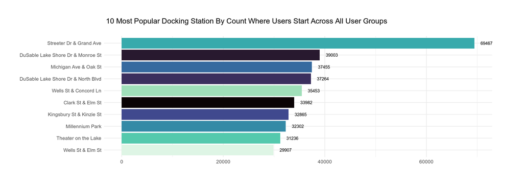

```r
df_popular_start_station <- df %>%
    select(start_station_name) %>%
    table() %>%
    as_tibble() %>%
    setNames(c("start_station_name", "count")) %>%
    mutate(relative_frequency = count / nrow(df)) %>%
    arrange(desc(count)) %>%
    head(10)

plot_popular_station(
    x = df_popular_start_station$count,
    y = df_popular_start_station$start_station_name,
    title = "10 Most Popular Docking Station By Count Where Users Start Across All User Groups")
```

Getting the top 10 most popular end station

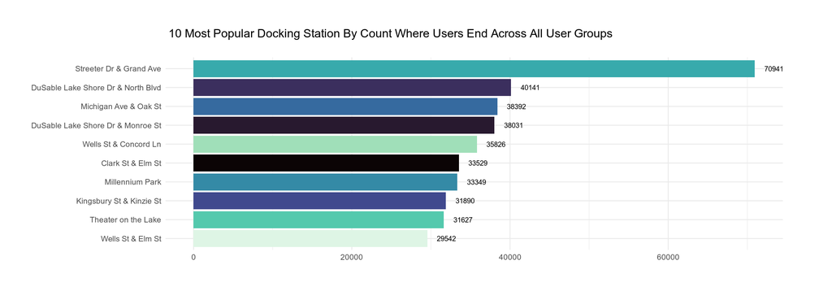

```r
df_popular_end_station <- df %>%
    select(end_station_name) %>%
    table() %>%
    as_tibble() %>%
    setNames(c("end_station_name", "count")) %>%
    mutate(relative_frequency = count / nrow(df)) %>%
    arrange(desc(count)) %>%
    head(10)

plot_popular_station(
    x = df_popular_end_station$count,
    y = df_popular_end_station$end_station_name,
    title = "10 Most Popular Docking Station By Count Where Users End Across All User Groups")
```

Plotting the stations where users start in coordinate view

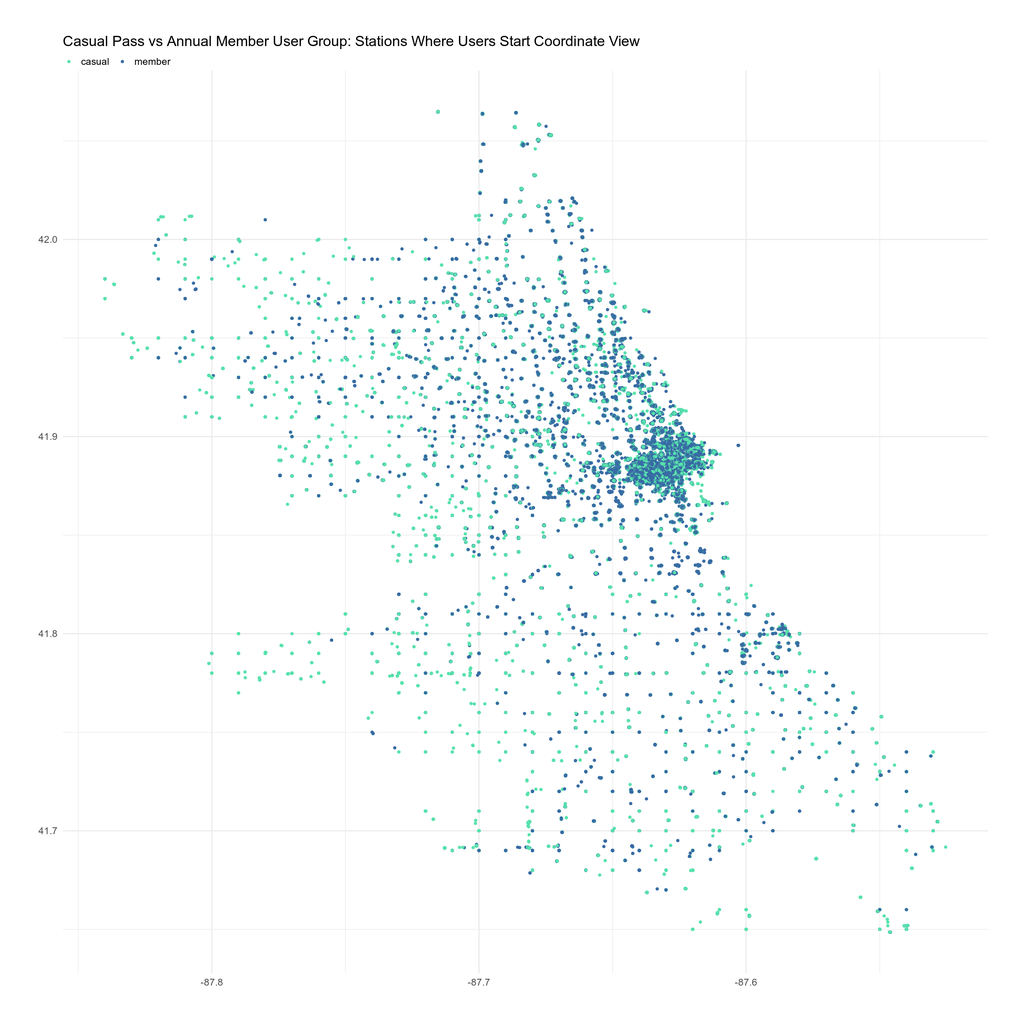

```r
options(repr.plot.width=20, repr.plot.height=20)

df %>%
    ggplot(mapping = aes(x = start_lng, y = start_lat)) +
    geom_point(mapping = aes(color = member_casual)) +
    labs(title = "\nCasual Pass vs Annual Member User Group: Stations Where Users Start Coordinate View\n") +
    scale_color_manual(values = c("#58e2ad", "#386ba4")) +
    theme_minimal(base_size = 17) +
    theme(
        plot.margin = margin(1,1.8,1.8,1.9, "cm"),
        axis.title.y = element_blank(), axis.title.x = element_blank(),
        legend.position = c(0.055, 1.01), legend.title = element_blank(), legend.direction = "horizontal")
```

Chicago neighborhood map

[figure not shown]

#### Key findings: Trends, relationships, and the inconclusive findings

**Inconclusive findings and speculations**

- Members get more out of the service by using it to commute consistently based on the factors that members:
  - Are particularly more active during wednesdays and thursdays
  - Bike usage dips after friday
  - Shows to have a dense amount of observations focusing around the downtown area where most of them start on